# Risk Factor Analysis

## Outcome Variable

**Outcome Variable:** wasted

## Predictor Variables

**Intervention Variable:** meducyrs

**Adjustment Set:**

- arm
- W_mage
- feducyrs
- hhwealth_quart
- W_mhtcm
- W_gagebrth
- W_birthwt
- W_birthlen
- W_nrooms
- impfloor
- impsan
- safeh20
- delta_W_mage
- delta_feducyrs
- delta_hhwealth_quart
- delta_W_mhtcm
- delta_W_gagebrth
- delta_W_birthwt
- delta_W_birthlen
- delta_W_nrooms
- delta_impfloor
- delta_impsan
- delta_safeh20

## Stratifying Variables

The analysis was stratified on these variable(s):

- agecat
- studyid
- country

## Data Summary

| agecat | studyid | country | meducyrs | wasted | n_cell | n |
| --- | --- | --- | --- | --- | --- | --- |
| Birth | ki0047075b-MAL-ED | BANGLADESH | Low | 0 | 54 | 195 |
| Birth | ki0047075b-MAL-ED | BANGLADESH | Low | 1 | 9 | 195 |
| Birth | ki0047075b-MAL-ED | BANGLADESH | Medium | 0 | 45 | 195 |
| Birth | ki0047075b-MAL-ED | BANGLADESH | Medium | 1 | 15 | 195 |
| Birth | ki0047075b-MAL-ED | BANGLADESH | High | 0 | 63 | 195 |
| Birth | ki0047075b-MAL-ED | BANGLADESH | High | 1 | 9 | 195 |
| Birth | ki0047075b-MAL-ED | BRAZIL | Low | 0 | 48 | 182 |
| Birth | ki0047075b-MAL-ED | BRAZIL | Low | 1 | 3 | 182 |
| Birth | ki0047075b-MAL-ED | BRAZIL | Medium | 0 | 65 | 182 |
| Birth | ki0047075b-MAL-ED | BRAZIL | Medium | 1 | 3 | 182 |
| Birth | ki0047075b-MAL-ED | BRAZIL | High | 0 | 63 | 182 |
| Birth | ki0047075b-MAL-ED | BRAZIL | High | 1 | 0 | 182 |
| Birth | ki0047075b-MAL-ED | INDIA | Low | 0 | 48 | 180 |
| Birth | ki0047075b-MAL-ED | INDIA | Low | 1 | 12 | 180 |
| Birth | ki0047075b-MAL-ED | INDIA | Medium | 0 | 55 | 180 |
| Birth | ki0047075b-MAL-ED | INDIA | Medium | 1 | 14 | 180 |
| Birth | ki0047075b-MAL-ED | INDIA | High | 0 | 47 | 180 |
| Birth | ki0047075b-MAL-ED | INDIA | High | 1 | 4 | 180 |
| Birth | ki0047075b-MAL-ED | NEPAL | Low | 0 | 61 | 155 |
| Birth | ki0047075b-MAL-ED | NEPAL | Low | 1 | 4 | 155 |
| Birth | ki0047075b-MAL-ED | NEPAL | Medium | 0 | 45 | 155 |
| Birth | ki0047075b-MAL-ED | NEPAL | Medium | 1 | 8 | 155 |
| Birth | ki0047075b-MAL-ED | NEPAL | High | 0 | 30 | 155 |
| Birth | ki0047075b-MAL-ED | NEPAL | High | 1 | 7 | 155 |
| Birth | ki0047075b-MAL-ED | PERU | Low | 0 | 98 | 278 |
| Birth | ki0047075b-MAL-ED | PERU | Low | 1 | 0 | 278 |
| Birth | ki0047075b-MAL-ED | PERU | Medium | 0 | 94 | 278 |
| Birth | ki0047075b-MAL-ED | PERU | Medium | 1 | 4 | 278 |
| Birth | ki0047075b-MAL-ED | PERU | High | 0 | 80 | 278 |
| Birth | ki0047075b-MAL-ED | PERU | High | 1 | 2 | 278 |

[output cut: 378 more lines]

The following strata were considered:

- agecat: 24 months, studyid: ki0047075b-MAL-ED, country: BANGLADESH
- agecat: 24 months, studyid: ki0047075b-MAL-ED, country: BRAZIL
- agecat: 24 months, studyid: ki0047075b-MAL-ED, country: INDIA
- agecat: 24 months, studyid: ki0047075b-MAL-ED, country: NEPAL
- agecat: 24 months, studyid: ki0047075b-MAL-ED, country: PERU
- agecat: 24 months, studyid: ki0047075b-MAL-ED, country: SOUTH AFRICA
- agecat: 24 months, studyid: ki0047075b-MAL-ED, country: TANZANIA, UNITED REPUBLIC OF
- agecat: 24 months, studyid: ki1000108-CMC-V-BCS-2002, country: INDIA
- agecat: 24 months, studyid: ki1000108-IRC, country: INDIA
- agecat: 24 months, studyid: ki1017093-NIH-Birth, country: BANGLADESH
- agecat: 24 months, studyid: ki1017093b-PROVIDE, country: BANGLADESH
- agecat: 24 months, studyid: ki1017093c-NIH-Crypto, country: BANGLADESH
- agecat: 24 months, studyid: ki1066203-TanzaniaChild2, country: TANZANIA, UNITED REPUBLIC OF
- agecat: 24 months, studyid: ki1113344-GMS-Nepal, country: NEPAL
- agecat: 24 months, studyid: ki1119695-PROBIT, country: BELARUS
- agecat: 24 months, studyid: ki1126311-ZVITAMBO, country: ZIMBABWE
- agecat: 24 months, studyid: ki1135781-COHORTS, country: GUATEMALA
- agecat: 24 months, studyid: ki1135781-COHORTS, country: INDIA
- agecat: 24 months, studyid: ki1135781-COHORTS, country: PHILIPPINES
- agecat: 24 months, studyid: ki1148112-LCNI-5, country: MALAWI
- agecat: 24 months, studyid: kiGH5241-JiVitA-3, country: BANGLADESH
- agecat: 24 months, studyid: kiGH5241-JiVitA-4, country: BANGLADESH
- agecat: 6 months, studyid: ki0047075b-MAL-ED, country: BANGLADESH
- agecat: 6 months, studyid: ki0047075b-MAL-ED, country: BRAZIL
- agecat: 6 months, studyid: ki0047075b-MAL-ED, country: INDIA
- agecat: 6 months, studyid: ki0047075b-MAL-ED, country: NEPAL
- agecat: 6 months, studyid: ki0047075b-MAL-ED, country: PERU
- agecat: 6 months, studyid: ki0047075b-MAL-ED, country: SOUTH AFRICA
- agecat: 6 months, studyid: ki0047075b-MAL-ED, country: TANZANIA, UNITED REPUBLIC OF
- agecat: 6 months, studyid: ki1000108-CMC-V-BCS-2002, country: INDIA
- agecat: 6 months, studyid: ki1000108-IRC, country: INDIA
- agecat: 6 months, studyid: ki1000109-EE, country: PAKISTAN
- agecat: 6 months, studyid: ki1000304b-SAS-CompFeed, country: INDIA
- agecat: 6 months, studyid: ki1000304b-SAS-FoodSuppl, country: INDIA
- agecat: 6 months, studyid: ki1017093-NIH-Birth, country: BANGLADESH
- agecat: 6 months, studyid: ki1017093b-PROVIDE, country: BANGLADESH
- agecat: 6 months, studyid: ki1017093c-NIH-Crypto, country: BANGLADESH
- agecat: 6 months, studyid: ki1066203-TanzaniaChild2, country: TANZANIA, UNITED REPUBLIC OF
- agecat: 6 months, studyid: ki1112895-Guatemala BSC, country: GUATEMALA
- agecat: 6 months, studyid: ki1113344-GMS-Nepal, country: NEPAL
- agecat: 6 months, studyid: ki1119695-PROBIT, country: BELARUS
- agecat: 6 months, studyid: ki1126311-ZVITAMBO, country: ZIMBABWE
- agecat: 6 months, studyid: ki1135781-COHORTS, country: GUATEMALA
- agecat: 6 months, studyid: ki1135781-COHORTS, country: INDIA
- agecat: 6 months, studyid: ki1135781-COHORTS, country: PHILIPPINES
- agecat: 6 months, studyid: ki1148112-LCNI-5, country: MALAWI
- agecat: 6 months, studyid: kiGH5241-JiVitA-3, country: BANGLADESH
- agecat: 6 months, studyid: kiGH5241-JiVitA-4, country: BANGLADESH
- agecat: Birth, studyid: ki0047075b-MAL-ED, country: BANGLADESH
- agecat: Birth, studyid: ki0047075b-MAL-ED, country: BRAZIL
- agecat: Birth, studyid: ki0047075b-MAL-ED, country: INDIA
- agecat: Birth, studyid: ki0047075b-MAL-ED, country: NEPAL
- agecat: Birth, studyid: ki0047075b-MAL-ED, country: PERU
- agecat: Birth, studyid: ki0047075b-MAL-ED, country: SOUTH AFRICA
- agecat: Birth, studyid: ki0047075b-MAL-ED, country: TANZANIA, UNITED REPUBLIC OF
- agecat: Birth, studyid: ki1000108-CMC-V-BCS-2002, country: INDIA
- agecat: Birth, studyid: ki1000108-IRC, country: INDIA
- agecat: Birth, studyid: ki1000109-EE, country: PAKISTAN
- agecat: Birth, studyid: ki1000304b-SAS-CompFeed, country: INDIA
- agecat: Birth, studyid: ki1017093-NIH-Birth, country: BANGLADESH
- agecat: Birth, studyid: ki1017093c-NIH-Crypto, country: BANGLADESH
- agecat: Birth, studyid: ki1119695-PROBIT, country: BELARUS
- agecat: Birth, studyid: ki1126311-ZVITAMBO, country: ZIMBABWE
- agecat: Birth, studyid: ki1135781-COHORTS, country: GUATEMALA
- agecat: Birth, studyid: ki1135781-COHORTS, country: INDIA
- agecat: Birth, studyid: ki1135781-COHORTS, country: PHILIPPINES
- agecat: Birth, studyid: kiGH5241-JiVitA-3, country: BANGLADESH
- agecat: Birth, studyid: kiGH5241-JiVitA-4, country: BANGLADESH

### Dropped Strata

Some strata were dropped due to rare outcomes:

- agecat: Birth, studyid: ki0047075b-MAL-ED, country: BRAZIL
- agecat: Birth, studyid: ki0047075b-MAL-ED, country: INDIA
- agecat: Birth, studyid: ki0047075b-MAL-ED, country: NEPAL
- agecat: Birth, studyid: ki0047075b-MAL-ED, country: PERU
- agecat: Birth, studyid: ki0047075b-MAL-ED, country: SOUTH AFRICA
- agecat: Birth, studyid: ki0047075b-MAL-ED, country: TANZANIA, UNITED REPUBLIC OF
- agecat: Birth, studyid: ki1000108-CMC-V-BCS-2002, country: INDIA
- agecat: Birth, studyid: ki1000109-EE, country: PAKISTAN
- agecat: Birth, studyid: ki1000304b-SAS-CompFeed, country: INDIA
- agecat: Birth, studyid: ki1017093-NIH-Birth, country: BANGLADESH
- agecat: Birth, studyid: ki1017093c-NIH-Crypto, country: BANGLADESH
- agecat: Birth, studyid: kiGH5241-JiVitA-4, country: BANGLADESH
- agecat: 6 months, studyid: ki0047075b-MAL-ED, country: BANGLADESH
- agecat: 6 months, studyid: ki0047075b-MAL-ED, country: BRAZIL
- agecat: 6 months, studyid: ki0047075b-MAL-ED, country: NEPAL
- agecat: 6 months, studyid: ki0047075b-MAL-ED, country: PERU
- agecat: 6 months, studyid: ki0047075b-MAL-ED, country: SOUTH AFRICA
- agecat: 6 months, studyid: ki0047075b-MAL-ED, country: TANZANIA, UNITED REPUBLIC OF
- agecat: 6 months, studyid: ki1000109-EE, country: PAKISTAN
- agecat: 6 months, studyid: ki1000304b-SAS-FoodSuppl, country: INDIA
- agecat: 6 months, studyid: ki1017093c-NIH-Crypto, country: BANGLADESH
- agecat: 6 months, studyid: ki1066203-TanzaniaChild2, country: TANZANIA, UNITED REPUBLIC OF
- agecat: 6 months, studyid: ki1112895-Guatemala BSC, country: GUATEMALA
- agecat: 6 months, studyid: ki1148112-LCNI-5, country: MALAWI
- agecat: 6 months, studyid: kiGH5241-JiVitA-4, country: BANGLADESH
- agecat: 24 months, studyid: ki0047075b-MAL-ED, country: BANGLADESH
- agecat: 24 months, studyid: ki0047075b-MAL-ED, country: BRAZIL
- agecat: 24 months, studyid: ki0047075b-MAL-ED, country: INDIA
- agecat: 24 months, studyid: ki0047075b-MAL-ED, country: NEPAL
- agecat: 24 months, studyid: ki0047075b-MAL-ED, country: PERU
- agecat: 24 months, studyid: ki0047075b-MAL-ED, country: SOUTH AFRICA
- agecat: 24 months, studyid: ki0047075b-MAL-ED, country: TANZANIA, UNITED REPUBLIC OF
- agecat: 24 months, studyid: ki1066203-TanzaniaChild2, country: TANZANIA, UNITED REPUBLIC OF
- agecat: 24 months, studyid: ki1148112-LCNI-5, country: MALAWI

## Methods Detail

We’re interested in the causal parameters $E[Y_a]$ for all values of $a \in \mathcal{A}$. These parameters represent the mean outcome if, possibly contrary to fact, we intervened to set all units to have $A=a$. Under the randomization and positivity assumptions, these are identified by the statistical parameters $\psi_a=E_W[E_{Y|A,W}(Y|A=a,W)]$. In addition, we’re interested in the mean of $Y$, $E[Y]$ under no intervention (the observed mean). We will estimate these parameters by using SuperLearner to fit the relevant likelihood factors – $E_{Y|A,W}(Y|A=a,W)$ and $p(A=a|W)$, and then updating our likelihood fit using a joint TMLE.

For unadjusted analyses ($W=\{\}$), initial likelihoods were estimated using Lrnr_glm to estimate the simple $E(Y|A)$ and Lrnr_mean to estimate $p(A)$. For adjusted analyses, a small library containing Lrnr_glmnet, Lrnr_xgboost, and Lrnr_mean was used.

Having estimated these parameters, we will then use the delta method to estimate relative risks and attributable risks relative to a prespecified baseline level of $A$.

# Results Detail

## Results Plots

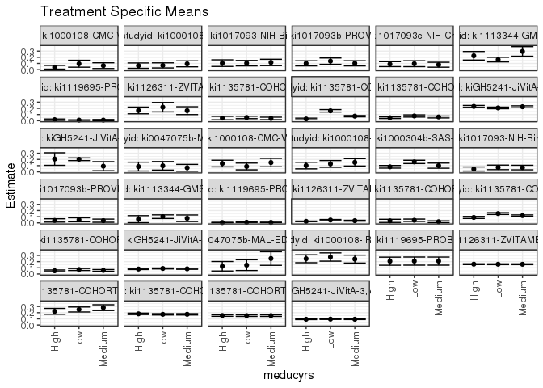

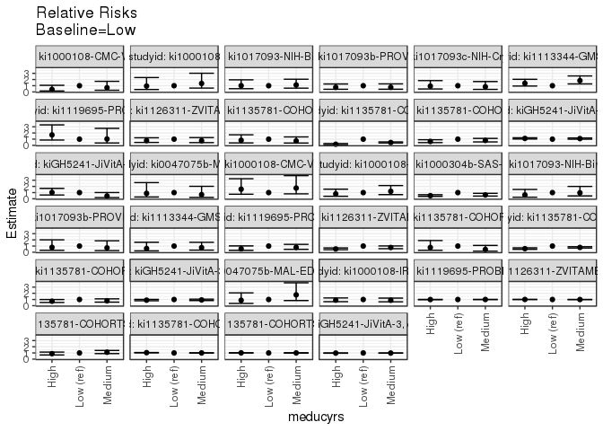

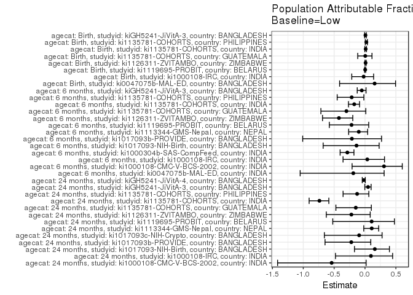

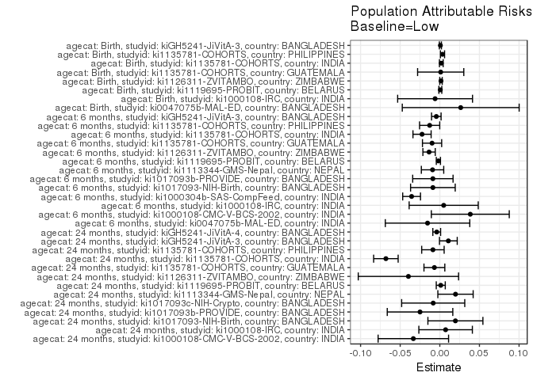

## Results Table

### Parameter: TSM

| agecat | studyid | country | intervention_level | baseline_level | estimate | ci_lower | ci_upper |
| --- | --- | --- | --- | --- | --- | --- | --- |
| Birth | ki0047075b-MAL-ED | BANGLADESH | Low | NA | 0.1428571 | 0.0562264 | 0.2294878 |
| Birth | ki0047075b-MAL-ED | BANGLADESH | Medium | NA | 0.2500000 | 0.1401527 | 0.3598473 |
| Birth | ki0047075b-MAL-ED | BANGLADESH | High | NA | 0.1250000 | 0.0484126 | 0.2015874 |
| Birth | ki1000108-IRC | INDIA | Low | NA | 0.2741869 | 0.2074821 | 0.3408918 |
| Birth | ki1000108-IRC | INDIA | Medium | NA | 0.2408244 | 0.1768332 | 0.3048155 |
| Birth | ki1000108-IRC | INDIA | High | NA | 0.2463493 | 0.1821580 | 0.3105406 |
| Birth | ki1119695-PROBIT | BELARUS | Low | NA | 0.2082747 | 0.1428673 | 0.2736821 |
| Birth | ki1119695-PROBIT | BELARUS | Medium | NA | 0.2081220 | 0.1430250 | 0.2732189 |
| Birth | ki1119695-PROBIT | BELARUS | High | NA | 0.2065704 | 0.1413404 | 0.2718003 |
| Birth | ki1126311-ZVITAMBO | ZIMBABWE | Low | NA | 0.1579513 | 0.1515030 | 0.1643996 |
| Birth | ki1126311-ZVITAMBO | ZIMBABWE | Medium | NA | 0.1573594 | 0.1509762 | 0.1637426 |
| Birth | ki1126311-ZVITAMBO | ZIMBABWE | High | NA | 0.1588277 | 0.1524883 | 0.1651672 |
| Birth | ki1135781-COHORTS | GUATEMALA | Low | NA | 0.2515643 | 0.2113659 | 0.2917627 |
| Birth | ki1135781-COHORTS | GUATEMALA | Medium | NA | 0.2815117 | 0.2344589 | 0.3285646 |
| Birth | ki1135781-COHORTS | GUATEMALA | High | NA | 0.2218820 | 0.1738939 | 0.2698701 |
| Birth | ki1135781-COHORTS | INDIA | Low | NA | 0.1731637 | 0.1623856 | 0.1839419 |
| Birth | ki1135781-COHORTS | INDIA | Medium | NA | 0.1736860 | 0.1629856 | 0.1843864 |
| Birth | ki1135781-COHORTS | INDIA | High | NA | 0.1810917 | 0.1698345 | 0.1923489 |
| Birth | ki1135781-COHORTS | PHILIPPINES | Low | NA | 0.1521671 | 0.1391114 | 0.1652228 |
| Birth | ki1135781-COHORTS | PHILIPPINES | Medium | NA | 0.1523540 | 0.1388712 | 0.1658367 |
| Birth | ki1135781-COHORTS | PHILIPPINES | High | NA | 0.1539194 | 0.1407685 | 0.1670703 |
| Birth | kiGH5241-JiVitA-3 | BANGLADESH | Low | NA | 0.0953011 | 0.0899455 | 0.1006566 |
| Birth | kiGH5241-JiVitA-3 | BANGLADESH | Medium | NA | 0.0935899 | 0.0881936 | 0.0989862 |
| Birth | kiGH5241-JiVitA-3 | BANGLADESH | High | NA | 0.0933311 | 0.0880449 | 0.0986172 |
| 6 months | ki0047075b-MAL-ED | INDIA | Low | NA | 0.0972222 | 0.0286258 | 0.1658187 |
| 6 months | ki0047075b-MAL-ED | INDIA | Medium | NA | 0.0649351 | 0.0097642 | 0.1201059 |
| 6 months | ki0047075b-MAL-ED | INDIA | High | NA | 0.0847458 | 0.0135099 | 0.1559816 |
| 6 months | ki1000108-CMC-V-BCS-2002 | INDIA | Low | NA | 0.0865385 | 0.0324291 | 0.1406478 |
| 6 months | ki1000108-CMC-V-BCS-2002 | INDIA | Medium | NA | 0.1495327 | 0.0818708 | 0.2171946 |
| 6 months | ki1000108-CMC-V-BCS-2002 | INDIA | High | NA | 0.1337580 | 0.0804406 | 0.1870753 |

[output cut: 72 more lines]

### Parameter: E(Y)

| agecat | studyid | country | intervention_level | baseline_level | estimate | ci_lower | ci_upper |
| --- | --- | --- | --- | --- | --- | --- | --- |
| Birth | ki0047075b-MAL-ED | BANGLADESH | NA | NA | 0.1692308 | 0.1164681 | 0.2219935 |
| Birth | ki1000108-IRC | INDIA | NA | NA | 0.2682216 | 0.2212677 | 0.3151755 |
| Birth | ki1119695-PROBIT | BELARUS | NA | NA | 0.2089120 | 0.1435514 | 0.2742726 |
| Birth | ki1126311-ZVITAMBO | ZIMBABWE | NA | NA | 0.1594293 | 0.1531109 | 0.1657477 |
| Birth | ki1135781-COHORTS | GUATEMALA | NA | NA | 0.2526738 | 0.2215120 | 0.2838356 |
| Birth | ki1135781-COHORTS | INDIA | NA | NA | 0.1750359 | 0.1643722 | 0.1856996 |
| Birth | ki1135781-COHORTS | PHILIPPINES | NA | NA | 0.1555709 | 0.1423748 | 0.1687670 |
| Birth | kiGH5241-JiVitA-3 | BANGLADESH | NA | NA | 0.0960153 | 0.0908094 | 0.1012212 |
| 6 months | ki0047075b-MAL-ED | INDIA | NA | NA | 0.0817308 | 0.0444108 | 0.1190507 |
| 6 months | ki1000108-CMC-V-BCS-2002 | INDIA | NA | NA | 0.1250000 | 0.0911644 | 0.1588356 |
| 6 months | ki1000108-IRC | INDIA | NA | NA | 0.1323529 | 0.0994307 | 0.1652752 |
| 6 months | ki1000304b-SAS-CompFeed | INDIA | NA | NA | 0.1244378 | 0.0992652 | 0.1496104 |
| 6 months | ki1017093-NIH-Birth | BANGLADESH | NA | NA | 0.0634328 | 0.0427791 | 0.0840865 |
| 6 months | ki1017093b-PROVIDE | BANGLADESH | NA | NA | 0.0412371 | 0.0250690 | 0.0574052 |
| 6 months | ki1113344-GMS-Nepal | NEPAL | NA | NA | 0.0910714 | 0.0672209 | 0.1149220 |
| 6 months | ki1119695-PROBIT | BELARUS | NA | NA | 0.0082503 | 0.0066012 | 0.0098994 |
| 6 months | ki1126311-ZVITAMBO | ZIMBABWE | NA | NA | 0.0321173 | 0.0283128 | 0.0359219 |
| 6 months | ki1135781-COHORTS | GUATEMALA | NA | NA | 0.0325289 | 0.0212599 | 0.0437978 |
| 6 months | ki1135781-COHORTS | INDIA | NA | NA | 0.1283521 | 0.1194359 | 0.1372684 |
| 6 months | ki1135781-COHORTS | PHILIPPINES | NA | NA | 0.0594974 | 0.0505830 | 0.0684118 |
| 6 months | kiGH5241-JiVitA-3 | BANGLADESH | NA | NA | 0.0847144 | 0.0799093 | 0.0895194 |
| 24 months | ki1000108-CMC-V-BCS-2002 | INDIA | NA | NA | 0.0618280 | 0.0373207 | 0.0863352 |
| 24 months | ki1000108-IRC | INDIA | NA | NA | 0.0757946 | 0.0501131 | 0.1014762 |
| 24 months | ki1017093-NIH-Birth | BANGLADESH | NA | NA | 0.1238318 | 0.0925894 | 0.1550741 |
| 24 months | ki1017093b-PROVIDE | BANGLADESH | NA | NA | 0.1124567 | 0.0866788 | 0.1382347 |
| 24 months | ki1017093c-NIH-Crypto | BANGLADESH | NA | NA | 0.0875486 | 0.0630907 | 0.1120065 |
| 24 months | ki1113344-GMS-Nepal | NEPAL | NA | NA | 0.1818182 | 0.1478065 | 0.2158299 |
| 24 months | ki1119695-PROBIT | BELARUS | NA | NA | 0.0110803 | 0.0050506 | 0.0171100 |
| 24 months | ki1126311-ZVITAMBO | ZIMBABWE | NA | NA | 0.1796690 | 0.1430402 | 0.2162979 |
| 24 months | ki1135781-COHORTS | GUATEMALA | NA | NA | 0.0458801 | 0.0333262 | 0.0584341 |
| 24 months | ki1135781-COHORTS | INDIA | NA | NA | 0.0921747 | 0.0833896 | 0.1009599 |
| 24 months | ki1135781-COHORTS | PHILIPPINES | NA | NA | 0.0681911 | 0.0582056 | 0.0781766 |
| 24 months | kiGH5241-JiVitA-3 | BANGLADESH | NA | NA | 0.2183600 | 0.2084428 | 0.2282771 |
| 24 months | kiGH5241-JiVitA-4 | BANGLADESH | NA | NA | 0.1990788 | 0.1780707 | 0.2200869 |

### Parameter: RR

| agecat | studyid | country | intervention_level | baseline_level | estimate | ci_lower | ci_upper |
| --- | --- | --- | --- | --- | --- | --- | --- |
| Birth | ki0047075b-MAL-ED | BANGLADESH | Low | Low | 1.0000000 | 1.0000000 | 1.0000000 |
| Birth | ki0047075b-MAL-ED | BANGLADESH | Medium | Low | 1.7500000 | 0.8275784 | 3.7005556 |
| Birth | ki0047075b-MAL-ED | BANGLADESH | High | Low | 0.8750000 | 0.3695066 | 2.0720199 |
| Birth | ki1000108-IRC | INDIA | Low | Low | 1.0000000 | 1.0000000 | 1.0000000 |
| Birth | ki1000108-IRC | INDIA | Medium | Low | 0.8783217 | 0.6296056 | 1.2252894 |
| Birth | ki1000108-IRC | INDIA | High | Low | 0.8984721 | 0.6475103 | 1.2467014 |
| Birth | ki1119695-PROBIT | BELARUS | Low | Low | 1.0000000 | 1.0000000 | 1.0000000 |
| Birth | ki1119695-PROBIT | BELARUS | Medium | Low | 0.9992668 | 0.9853385 | 1.0133920 |
| Birth | ki1119695-PROBIT | BELARUS | High | Low | 0.9918169 | 0.9733681 | 1.0106153 |
| Birth | ki1126311-ZVITAMBO | ZIMBABWE | Low | Low | 1.0000000 | 1.0000000 | 1.0000000 |
| Birth | ki1126311-ZVITAMBO | ZIMBABWE | Medium | Low | 0.9962526 | 0.9823666 | 1.0103350 |
| Birth | ki1126311-ZVITAMBO | ZIMBABWE | High | Low | 1.0055489 | 0.9925201 | 1.0187487 |
| Birth | ki1135781-COHORTS | GUATEMALA | Low | Low | 1.0000000 | 1.0000000 | 1.0000000 |
| Birth | ki1135781-COHORTS | GUATEMALA | Medium | Low | 1.1190449 | 0.8941804 | 1.4004573 |
| Birth | ki1135781-COHORTS | GUATEMALA | High | Low | 0.8820092 | 0.6801422 | 1.1437906 |
| Birth | ki1135781-COHORTS | INDIA | Low | Low | 1.0000000 | 1.0000000 | 1.0000000 |
| Birth | ki1135781-COHORTS | INDIA | Medium | Low | 1.0030161 | 0.9822385 | 1.0242331 |
| Birth | ki1135781-COHORTS | INDIA | High | Low | 1.0457830 | 1.0176364 | 1.0747080 |
| Birth | ki1135781-COHORTS | PHILIPPINES | Low | Low | 1.0000000 | 1.0000000 | 1.0000000 |
| Birth | ki1135781-COHORTS | PHILIPPINES | Medium | Low | 1.0012281 | 0.9696568 | 1.0338273 |
| Birth | ki1135781-COHORTS | PHILIPPINES | High | Low | 1.0115157 | 0.9898550 | 1.0336505 |
| Birth | kiGH5241-JiVitA-3 | BANGLADESH | Low | Low | 1.0000000 | 1.0000000 | 1.0000000 |
| Birth | kiGH5241-JiVitA-3 | BANGLADESH | Medium | Low | 0.9820445 | 0.9564753 | 1.0082973 |
| Birth | kiGH5241-JiVitA-3 | BANGLADESH | High | Low | 0.9793289 | 0.9533579 | 1.0060074 |
| 6 months | ki0047075b-MAL-ED | INDIA | Low | Low | 1.0000000 | 1.0000000 | 1.0000000 |
| 6 months | ki0047075b-MAL-ED | INDIA | Medium | Low | 0.6679035 | 0.2213503 | 2.0153351 |
| 6 months | ki0047075b-MAL-ED | INDIA | High | Low | 0.8716707 | 0.2908945 | 2.6119773 |
| 6 months | ki1000108-CMC-V-BCS-2002 | INDIA | Low | Low | 1.0000000 | 1.0000000 | 1.0000000 |
| 6 months | ki1000108-CMC-V-BCS-2002 | INDIA | Medium | Low | 1.7279335 | 0.7986041 | 3.7387163 |
| 6 months | ki1000108-CMC-V-BCS-2002 | INDIA | High | Low | 1.5456476 | 0.7363336 | 3.2444893 |

[output cut: 72 more lines]

### Parameter: PAR

| agecat | studyid | country | intervention_level | baseline_level | estimate | ci_lower | ci_upper |
| --- | --- | --- | --- | --- | --- | --- | --- |
| Birth | ki0047075b-MAL-ED | BANGLADESH | Low | NA | 0.0263736 | -0.0473792 | 0.1001264 |
| Birth | ki1000108-IRC | INDIA | Low | NA | -0.0059654 | -0.0531985 | 0.0412678 |
| Birth | ki1119695-PROBIT | BELARUS | Low | NA | 0.0006373 | -0.0012264 | 0.0025011 |
| Birth | ki1126311-ZVITAMBO | ZIMBABWE | Low | NA | 0.0014780 | -0.0000910 | 0.0030470 |
| Birth | ki1135781-COHORTS | GUATEMALA | Low | NA | 0.0011095 | -0.0280360 | 0.0302550 |
| Birth | ki1135781-COHORTS | INDIA | Low | NA | 0.0018721 | -0.0004753 | 0.0042195 |
| Birth | ki1135781-COHORTS | PHILIPPINES | Low | NA | 0.0034038 | 0.0007969 | 0.0060107 |
| Birth | kiGH5241-JiVitA-3 | BANGLADESH | Low | NA | 0.0007142 | -0.0005959 | 0.0020244 |
| 6 months | ki0047075b-MAL-ED | INDIA | Low | NA | -0.0154915 | -0.0687889 | 0.0378060 |
| 6 months | ki1000108-CMC-V-BCS-2002 | INDIA | Low | NA | 0.0384615 | -0.0107097 | 0.0876328 |
| 6 months | ki1000108-IRC | INDIA | Low | NA | 0.0048875 | -0.0387051 | 0.0484800 |
| 6 months | ki1000304b-SAS-CompFeed | INDIA | Low | NA | -0.0356148 | -0.0468408 | -0.0243889 |
| 6 months | ki1017093-NIH-Birth | BANGLADESH | Low | NA | -0.0087321 | -0.0368986 | 0.0194344 |
| 6 months | ki1017093b-PROVIDE | BANGLADESH | Low | NA | -0.0087629 | -0.0342335 | 0.0167077 |
| 6 months | ki1113344-GMS-Nepal | NEPAL | Low | NA | -0.0091792 | -0.0232897 | 0.0049313 |
| 6 months | ki1119695-PROBIT | BELARUS | Low | NA | -0.0017975 | -0.0044273 | 0.0008323 |
| 6 months | ki1126311-ZVITAMBO | ZIMBABWE | Low | NA | -0.0135613 | -0.0213528 | -0.0057697 |
| 6 months | ki1135781-COHORTS | GUATEMALA | Low | NA | -0.0097874 | -0.0219126 | 0.0023378 |
| 6 months | ki1135781-COHORTS | INDIA | Low | NA | -0.0224273 | -0.0338902 | -0.0109645 |
| 6 months | ki1135781-COHORTS | PHILIPPINES | Low | NA | -0.0128238 | -0.0255467 | -0.0001009 |
| 6 months | kiGH5241-JiVitA-3 | BANGLADESH | Low | NA | -0.0044230 | -0.0104416 | 0.0015956 |
| 24 months | ki1000108-CMC-V-BCS-2002 | INDIA | Low | NA | -0.0334101 | -0.0778754 | 0.0110551 |
| 24 months | ki1000108-IRC | INDIA | Low | NA | 0.0073015 | -0.0264763 | 0.0410792 |
| 24 months | ki1017093-NIH-Birth | BANGLADESH | Low | NA | 0.0196699 | -0.0150381 | 0.0543779 |
| 24 months | ki1017093b-PROVIDE | BANGLADESH | Low | NA | -0.0249762 | -0.0663317 | 0.0163794 |
| 24 months | ki1017093c-NIH-Crypto | BANGLADESH | Low | NA | -0.0083418 | -0.0481579 | 0.0314743 |
| 24 months | ki1113344-GMS-Nepal | NEPAL | Low | NA | 0.0198038 | -0.0024752 | 0.0420827 |
| 24 months | ki1119695-PROBIT | BELARUS | Low | NA | 0.0011917 | -0.0044937 | 0.0068772 |
| 24 months | ki1126311-ZVITAMBO | ZIMBABWE | Low | NA | -0.0396292 | -0.1029341 | 0.0236757 |
| 24 months | ki1135781-COHORTS | GUATEMALA | Low | NA | -0.0068542 | -0.0200093 | 0.0063009 |
| 24 months | ki1135781-COHORTS | INDIA | Low | NA | -0.0680451 | -0.0835037 | -0.0525865 |
| 24 months | ki1135781-COHORTS | PHILIPPINES | Low | NA | -0.0087032 | -0.0228670 | 0.0054607 |
| 24 months | kiGH5241-JiVitA-3 | BANGLADESH | Low | NA | 0.0107823 | -0.0004132 | 0.0219778 |
| 24 months | kiGH5241-JiVitA-4 | BANGLADESH | Low | NA | -0.0039070 | -0.0088120 | 0.0009979 |

### Parameter: PAF

| agecat | studyid | country | intervention_level | baseline_level | estimate | ci_lower | ci_upper |
| --- | --- | --- | --- | --- | --- | --- | --- |
| Birth | ki0047075b-MAL-ED | BANGLADESH | Low | NA | 0.1558442 | -0.4116257 | 0.4951926 |
| Birth | ki1000108-IRC | INDIA | Low | NA | -0.0222404 | -0.2144522 | 0.1395499 |
| Birth | ki1119695-PROBIT | BELARUS | Low | NA | 0.0030508 | -0.0059723 | 0.0119929 |
| Birth | ki1126311-ZVITAMBO | ZIMBABWE | Low | NA | 0.0092705 | -0.0006120 | 0.0190554 |
| Birth | ki1135781-COHORTS | GUATEMALA | Low | NA | 0.0043910 | -0.1178378 | 0.1132548 |
| Birth | ki1135781-COHORTS | INDIA | Low | NA | 0.0106956 | -0.0027824 | 0.0239925 |
| Birth | ki1135781-COHORTS | PHILIPPINES | Low | NA | 0.0218792 | 0.0051618 | 0.0383157 |
| Birth | kiGH5241-JiVitA-3 | BANGLADESH | Low | NA | 0.0074389 | -0.0063021 | 0.0209923 |
| 6 months | ki0047075b-MAL-ED | INDIA | Low | NA | -0.1895425 | -1.0502290 | 0.3098277 |
| 6 months | ki1000108-CMC-V-BCS-2002 | INDIA | Low | NA | 0.3076923 | -0.2094506 | 0.6037127 |
| 6 months | ki1000108-IRC | INDIA | Low | NA | 0.0369274 | -0.3557148 | 0.3158526 |
| 6 months | ki1000304b-SAS-CompFeed | INDIA | Low | NA | -0.2862058 | -0.4029749 | -0.1791554 |
| 6 months | ki1017093-NIH-Birth | BANGLADESH | Low | NA | -0.1376592 | -0.6779854 | 0.2286772 |
| 6 months | ki1017093b-PROVIDE | BANGLADESH | Low | NA | -0.2125000 | -1.0095838 | 0.2684275 |
| 6 months | ki1113344-GMS-Nepal | NEPAL | Low | NA | -0.1007912 | -0.2651374 | 0.0422058 |
| 6 months | ki1119695-PROBIT | BELARUS | Low | NA | -0.2178757 | -0.5782162 | 0.0601913 |
| 6 months | ki1126311-ZVITAMBO | ZIMBABWE | Low | NA | -0.4222411 | -0.6882760 | -0.1981275 |
| 6 months | ki1135781-COHORTS | GUATEMALA | Low | NA | -0.3008837 | -0.7145811 | 0.0129960 |
| 6 months | ki1135781-COHORTS | INDIA | Low | NA | -0.1747329 | -0.2680596 | -0.0882750 |
| 6 months | ki1135781-COHORTS | PHILIPPINES | Low | NA | -0.2155354 | -0.4507293 | -0.0184713 |
| 6 months | kiGH5241-JiVitA-3 | BANGLADESH | Low | NA | -0.0522110 | -0.1259680 | 0.0167145 |
| 24 months | ki1000108-CMC-V-BCS-2002 | INDIA | Low | NA | -0.5403727 | -1.4159784 | 0.0178936 |
| 24 months | ki1000108-IRC | INDIA | Low | NA | 0.0963323 | -0.4780653 | 0.4475107 |
| 24 months | ki1017093-NIH-Birth | BANGLADESH | Low | NA | 0.1588437 | -0.1705944 | 0.3955687 |
| 24 months | ki1017093b-PROVIDE | BANGLADESH | Low | NA | -0.2220960 | -0.6476370 | 0.0935391 |
| 24 months | ki1017093c-NIH-Crypto | BANGLADESH | Low | NA | -0.0952816 | -0.6581031 | 0.2764975 |
| 24 months | ki1113344-GMS-Nepal | NEPAL | Low | NA | 0.1089206 | -0.0201981 | 0.2216978 |
| 24 months | ki1119695-PROBIT | BELARUS | Low | NA | 0.1075550 | -0.5223337 | 0.4768177 |
| 24 months | ki1126311-ZVITAMBO | ZIMBABWE | Low | NA | -0.2205679 | -0.6272484 | 0.0844754 |
| 24 months | ki1135781-COHORTS | GUATEMALA | Low | NA | -0.1493941 | -0.4717164 | 0.1023360 |
| 24 months | ki1135781-COHORTS | INDIA | Low | NA | -0.7382186 | -0.9051962 | -0.5858755 |
| 24 months | ki1135781-COHORTS | PHILIPPINES | Low | NA | -0.1276290 | -0.3551579 | 0.0616982 |
| 24 months | kiGH5241-JiVitA-3 | BANGLADESH | Low | NA | 0.0493787 | -0.0029137 | 0.0989445 |
| 24 months | kiGH5241-JiVitA-4 | BANGLADESH | Low | NA | -0.0196256 | -0.0444195 | 0.0045797 |